# Revision comments

# Revision comments

## 3. Fit statistics.

> 3. SPSS does not provide fit statistics for exploratory factor analysis. In order to convince me of the structure of your measure, you have to provide fit statistics. For example, M plus provides fit statistics for such analyses (also see reviewer 3; and M plus will provide geomin rotation), besides chi-squared, RMSEA (and confidence interval), also report at least CFI and TLI.

Response:

Here are the fit statistics for factor analytic solution in table and graphic format.

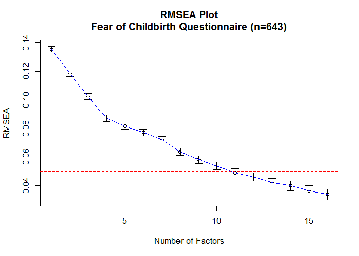

```
      Factors Cum.Eigen Chi-Square   Df p.value   RMSEA.Pt   RMSEA.Lo   RMSEA.Hi
 [1,]       1  15.54644  14390.417 1127       0 0.13539363 0.13342391 0.13737263
 [2,]       2  21.61655  10789.396 1079       0 0.11839687 0.11637184 0.12043263
 [3,]       3  24.63805   7965.640 1032       0 0.10229945 0.10021106 0.10440020
 [4,]       4  26.64605   5796.907  986       0 0.08717812 0.08501450 0.08935580
 [5,]       5  28.41399   4959.072  941       0 0.08155423 0.07932515 0.08379840
 [6,]       6  29.87331   4332.693  897       0 0.07724020 0.07494366 0.07955277
 [7,]       7  31.25113   3712.555  854       0 0.07220659 0.06983360 0.07459650
 [8,]       8  32.46623   2923.307  812       0 0.06364000 0.06116116 0.06613606
 [9,]       9  33.47568   2448.905  771       0 0.05822225 0.05563812 0.06082320
[10,]      10  34.47393   2092.926  731       0 0.05387044 0.05117417 0.05658229
[11,]      11  35.28305   1766.844  692       0 0.04918721 0.04635593 0.05203071
[12,]      12  36.07588   1549.766  654       0 0.04618925 0.04322740 0.04915953
[13,]      13  36.82597   1318.401  617       0 0.04207975 0.03894254 0.04521586
[14,]      14  37.54288   1176.173  581       0 0.03994533 0.03665421 0.04322725
[15,]      15  38.21977   1014.674  546       0 0.03656552 0.03305376 0.04004819
[16,]      16  38.85704    891.419  512       0 0.03397481 0.03023079 0.03766446
```

## 4. Number of factors

> Using the standard scree plot is an outdated approach to select the number of factors. So please follow his advice and apply a more advanced method such as parallel analysis or the MAP test or if you use a scree plot, do this on basis of fit statistics like for example the Hull method described by Lorenzo-Seva, Timmerman and Kiers (2011).

### PA with `psych`

Using `psych` package.

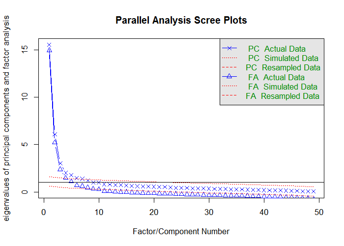

```
Parallel analysis suggests that the number of factors =  9  and the number of components =  7
```

```r
library(psych)
foc <- ds %>% dplyr::select_(.dots = items_phase_0)
foc <- matrix(as.numeric(unlist(foc)), nrow=nrow(foc), ncol=ncol(foc)) # turn it into a matrix

pa_result <- psych::fa.parallel(
  foc,
  fm = "uls",
  fa = "both",
  se.bars = TRUE
) # "Parallel analysis suggests that the number of factors =  9" (from "psych" package)
```

### PA with `nFactors`

Using `nFactors` package.

```r
library(nFactors)

# The nScree function returns an analysis of the number of component or factors to retain in an
# exploratory principal component or factor analysis. The function also returns information about the
# number of components/factors to retain with the Kaiser rule and the parallel analysis.
nFactors::nScree(x=eigen$values, model="factors")
```

```
  noc naf nparallel nkaiser
1   7   1         7       7
```

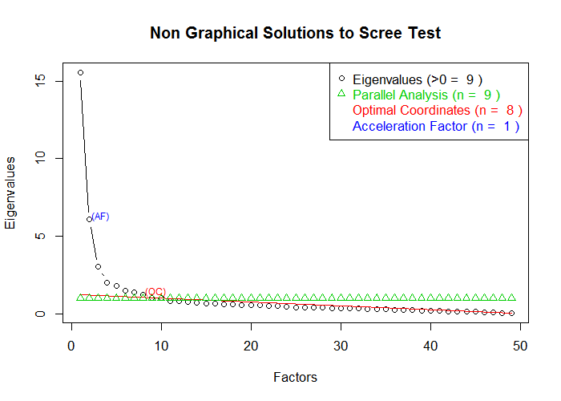

```r
nFactors::plotnScree(nFactors::nScree(x=eigen(R0)$values, model="factors")) # from nFactors package
```

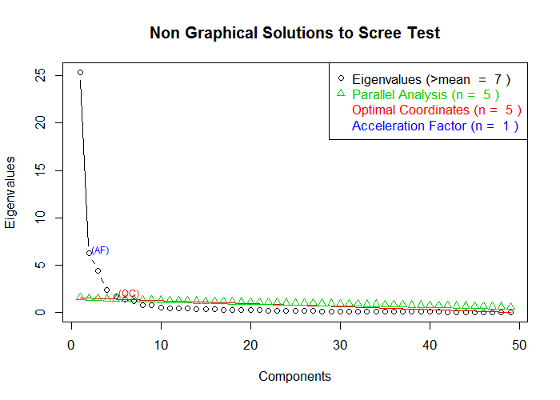

```r
# This function gives the distribution of the eigenvalues of correlation or a covariance matrices of
# random uncorrelated standardized normal variables. The mean and a selected quantile of this distribution
# are returned.
ap <- nFactors::parallel(subject=nrow(foc),var=ncol(foc),rep=1000,cent=.05)
nS <- nScree(x=eigen$values, aparallel=ap$eigen$qevpea)
plotnScree(nS)
```

```r
# Optimal Coordinates: 8
# Acceleration Factor: 1 (number before the point at which the line bends the most)
# Parallel Analysis: 9 (from Horn 1965)
# Eigenvalues: 9
```

### PA with simulation engine

Compare observed eigenvalues with values simulated by

> Patil, Vivek H., Surendra N. Singh, Sanjay Mishra,and D. Todd Donavan (2007), [Parallel Analysis Engine to Aid Determining Number of Factors to Retain](http://smishra.faculty.ku.edu/parallelengine.htm) [Computer software].

```
   observed_eignes Root    Means Percentile
1      15.54644434    1 1.574798   1.633146
2       6.07010077    2 1.518496   1.559414
3       3.02150467    3 1.474845   1.508177
4       2.00799598    4 1.439384   1.474861
5       1.76793924    5 1.407714   1.436193
6       1.45932867    6 1.379047   1.410655
7       1.37781562    7 1.348905   1.381205
8       1.21510142    8 1.322506   1.347220
9       1.00945024    9 1.298288   1.319829
10      0.99825234   10 1.271938   1.296358
11      0.80911734   11 1.249952   1.272519
12      0.79283408   12 1.227409   1.248755
13      0.75008165   13 1.205695   1.224794
14      0.71691233   14 1.182856   1.204474
```

[output cut: 35 more lines]

### Velicer’s MAP Test

```
Velicer's Minimum Average Partial Test


 The entered data is a correlation matrix.


Eigenvalues:

 root  eigenvalue
    1    15.54644
    2     6.07010
    3     3.02150
    4     2.00800
    5     1.76794
    6     1.45933
```

[output cut: 106 more lines]